# AIML_ML_Project_full_code_notebook

## Problem Statement

### **Full description**

#### Context

AllLife Bank is a US bank that has a growing customer base. The majority of these customers are liability customers (depositors) with varying sizes of deposits. The number of customers who are also borrowers (asset customers) is quite small, and the bank is interested in expanding this base rapidly to bring in more loan business and in the process, earn more through the interest on loans. In particular, the management wants to explore ways of converting its liability customers to personal loan customers (while retaining them as depositors).

A campaign that the bank ran last year for liability customers showed a healthy conversion rate of over 9% success. This has encouraged the retail marketing department to devise campaigns with better target marketing to increase the success ratio.

You as a Data scientist at AllLife bank have to build a model that will help the marketing department to identify the potential customers who have a higher probability of purchasing the loan.

#### Objective

To predict whether a liability customer will buy personal loans, to understand which customer attributes are most significant in driving purchases, and identify which segment of customers to target more.

#### Data Dictionary

- `ID`: Customer ID
- `Age`: Customer’s age in completed years
- `Experience`: #years of professional experience
- `Income`: Annual income of the customer (in thousand dollars)
- `ZIP Code`: Home Address ZIP code.
- `Family`: the Family size of the customer
- `CCAvg`: Average spending on credit cards per month (in thousand dollars)
- `Education`: Education Level. 1: Undergrad; 2: Graduate;3: Advanced/Professional
- `Mortgage`: Value of house mortgage if any. (in thousand dollars)
- `Personal_Loan`: Did this customer accept the personal loan offered in the last campaign? (0: No, 1: Yes)
- `Securities_Account`: Does the customer have securities account with the bank? (0: No, 1: Yes)
- `CD_Account`: Does the customer have a certificate of deposit (CD) account with the bank? (0: No, 1: Yes)
- `Online`: Do customers use internet banking facilities? (0: No, 1: Yes)
- `CreditCard`: Does the customer use a credit card issued by any other Bank (excluding All life Bank)? (0: No, 1: Yes)

### **Problem Statement Summary:**

AllLife Bank aims to increase its loan customer base by identifying liability customers with a higher probability of converting into personal loan customers. The objective is to build a predictive model to determine significant customer attributes driving loan uptake and segment customers for targeted marketing campaigns to maximize conversion rates while retaining them as depositors.

## Importing necessary libraries

```python
# Library for reading the data
import numpy as np
import pandas as pd

# Libraries for visualizing the data
import matplotlib.pyplot as plt
import seaborn as sns

# Libraries for working with model
from sklearn.model_selection import train_test_split
from sklearn.tree import DecisionTreeClassifier
from sklearn import tree

# Libraries for checking the metrics
from sklearn.metrics import (
    confusion_matrix,
    accuracy_score,
    recall_score,
    precision_score,
    f1_score
)
```

## Loading the dataset

```python
# getting access for reading data from google drive
from google.colab import drive
drive.mount('/content/drive')
```

```python
# Reading the data and make a copy of it
data = pd.read_csv('/content/drive/My Drive/Colab Notebooks/University Case Studies/Project 2 - ML/Loan_Modelling.csv')
df = data.copy()
```

## Data Overview

```python
# Checking the total rows and features
rows, cols = df.shape
print(f"The data has {rows} rows and {cols} columns")

# Delete un-used variables to release the memory
del rows, cols
```

```
The data has 5000 rows and 14 columns
```

```python
# Reading first 5th row
df.head()
```

|  | ID | Age | Experience | Income | ZIPCode | Family | CCAvg | Education | Mortgage | Personal_Loan | Securities_Account | CD_Account | Online | CreditCard |
| --- | --- | --- | --- | --- | --- | --- | --- | --- | --- | --- | --- | --- | --- | --- |
| 0 | 1 | 25 | 1 | 49 | 91107 | 4 | 1.6 | 1 | 0 | 0 | 1 | 0 | 0 | 0 |
| 1 | 2 | 45 | 19 | 34 | 90089 | 3 | 1.5 | 1 | 0 | 0 | 1 | 0 | 0 | 0 |
| 2 | 3 | 39 | 15 | 11 | 94720 | 1 | 1.0 | 1 | 0 | 0 | 0 | 0 | 0 | 0 |
| 3 | 4 | 35 | 9 | 100 | 94112 | 1 | 2.7 | 2 | 0 | 0 | 0 | 0 | 0 | 0 |
| 4 | 5 | 35 | 8 | 45 | 91330 | 4 | 1.0 | 2 | 0 | 0 | 0 | 0 | 0 | 1 |

```python
# Checking the types and general information
df.info()
```

```
<class 'pandas.core.frame.DataFrame'>
RangeIndex: 5000 entries, 0 to 4999
Data columns (total 14 columns):
 #   Column              Non-Null Count  Dtype
---  ------              --------------  -----
 0   ID                  5000 non-null   int64
 1   Age                 5000 non-null   int64
 2   Experience          5000 non-null   int64
 3   Income              5000 non-null   int64
 4   ZIPCode             5000 non-null   int64
 5   Family              5000 non-null   int64
 6   CCAvg               5000 non-null   float64
 7   Education           5000 non-null   int64
 8   Mortgage            5000 non-null   int64
 9   Personal_Loan       5000 non-null   int64
 10  Securities_Account  5000 non-null   int64
 11  CD_Account          5000 non-null   int64
 12  Online              5000 non-null   int64
 13  CreditCard          5000 non-null   int64
dtypes: float64(1), int64(13)
memory usage: 547.0 KB
```

**Data Types:**

- There are 13 int64 and 1 floating number

**Data Treatments**

- Since ZIPCode is stored as an integer, it’s likely not a truly numeric feature for modeling. I will treating it as a categorical feature.
- Features like ID are often unique identifiers and not used directly for modeling.

```python
# checking the statistics
df.describe().T
```

|  | count | mean | std | min | 25% | 50% | 75% | max |
| --- | --- | --- | --- | --- | --- | --- | --- | --- |
| ID | 5000.0 | 2500.500000 | 1443.520003 | 1.0 | 1250.75 | 2500.5 | 3750.25 | 5000.0 |
| Age | 5000.0 | 45.338400 | 11.463166 | 23.0 | 35.00 | 45.0 | 55.00 | 67.0 |
| Experience | 5000.0 | 20.104600 | 11.467954 | -3.0 | 10.00 | 20.0 | 30.00 | 43.0 |
| Income | 5000.0 | 73.774200 | 46.033729 | 8.0 | 39.00 | 64.0 | 98.00 | 224.0 |
| ZIPCode | 5000.0 | 93169.257000 | 1759.455086 | 90005.0 | 91911.00 | 93437.0 | 94608.00 | 96651.0 |
| Family | 5000.0 | 2.396400 | 1.147663 | 1.0 | 1.00 | 2.0 | 3.00 | 4.0 |
| CCAvg | 5000.0 | 1.937938 | 1.747659 | 0.0 | 0.70 | 1.5 | 2.50 | 10.0 |
| Education | 5000.0 | 1.881000 | 0.839869 | 1.0 | 1.00 | 2.0 | 3.00 | 3.0 |
| Mortgage | 5000.0 | 56.498800 | 101.713802 | 0.0 | 0.00 | 0.0 | 101.00 | 635.0 |
| Personal_Loan | 5000.0 | 0.096000 | 0.294621 | 0.0 | 0.00 | 0.0 | 0.00 | 1.0 |
| Securities_Account | 5000.0 | 0.104400 | 0.305809 | 0.0 | 0.00 | 0.0 | 0.00 | 1.0 |
| CD_Account | 5000.0 | 0.060400 | 0.238250 | 0.0 | 0.00 | 0.0 | 0.00 | 1.0 |
| Online | 5000.0 | 0.596800 | 0.490589 | 0.0 | 0.00 | 1.0 | 1.00 | 1.0 |
| CreditCard | 5000.0 | 0.294000 | 0.455637 | 0.0 | 0.00 | 0.0 | 1.00 | 1.0 |

Let's check each feature one by one:

**Age**

- With the mean of ~45 and std of ~11 and the range of 23 to 67, shows a moderate spread around the mean also it is obvious from 25% and 75% values.

**Experience**

- Ranges from -3 to 43 (mean ~20). A minimum of -3 might indicate data-entry errors. I may need to investigate further.

**Income**

- Goes from 8 to 224, with a mean of ~74. Potentially indicates a wide spread in incomes.

**ZIPCode**

- Even though it is numeric, it is likely categorical/non-numeric. I Will verify if ZIPCode should be used directly, mapped to regions, or dropped.

**Family**

- Has integer values from 1 to 4 (mean ~2.4), so small discrete categories.

**CCAvg**

- With the mean of ~2 and ranges from 0 to 10k, shows a skewed distribution.

**Education**

- Integer 1 to 3 (mean ~1.88). I will convert it to category type.

**Mortgage**

- Goes from 0 to 635, with a mean of ~56 and a high standard deviation, ~102. There may be outliers or a right-skewed distribution.

**Personal_Loan, Securities_Account, CD_Account, Online, CreditCard**

- These are 0/1 binary indicators

```python
# Checking the missing values
df.isna().sum()
```

|  | 0 |
| --- | --- |
| ID | 0 |
| Age | 0 |
| Experience | 0 |
| Income | 0 |
| ZIPCode | 0 |
| Family | 0 |
| CCAvg | 0 |
| Education | 0 |
| Mortgage | 0 |
| Personal_Loan | 0 |
| Securities_Account | 0 |
| CD_Account | 0 |
| Online | 0 |
| CreditCard | 0 |

**dtype:** int64

There is no missing values in the dataset

```python
# Checking data dupliucation
print(f"The number of duplicated rows: {df.duplicated().sum()}")
```

```
The number of duplicated rows: 0
```

## Feature engineering

### Experience

```python
# Checking unique values
df['Experience'].unique()
```

```
array([ 1, 19, 15,  9,  8, 13, 27, 24, 10, 39,  5, 23, 32, 41, 30, 14, 18,
       21, 28, 31, 11, 16, 20, 35,  6, 25,  7, 12, 26, 37, 17,  2, 36, 29,
        3, 22, -1, 34,  0, 38, 40, 33,  4, -2, 42, -3, 43])
```

As we can see, there is negative values for experience that may happen because of typing error, now we treat them and use abs function to make them positive

```python
# Replacing negative values with positive
df['Experience'] = df['Experience'].apply(abs)
df['Experience'].unique()
```

```
array([ 1, 19, 15,  9,  8, 13, 27, 24, 10, 39,  5, 23, 32, 41, 30, 14, 18,
       21, 28, 31, 11, 16, 20, 35,  6, 25,  7, 12, 26, 37, 17,  2, 36, 29,
        3, 22, 34,  0, 38, 40, 33,  4, 42, 43])
```

### ID

```python
# Drop the id column
df.drop('ID',axis=1, inplace=True)
```

### ZIP Code

The last 2 digits of ZIP codes showing the delivery area, So we can reduce the number to last 2 and convert them to category

```python
# Convert the ZIPCode column to string type to enable substring operations
# This ensures any numerical values in the ZIPCode column can be processed as strings
data["ZIPCode"] = data["ZIPCode"].astype(str)

# Calculate and print the number of unique values if we consider only the last two digits of ZIPCode
# The str[3:] slices the ZIPCode string to include only the last two characters
print(
    "Number of unique values if we take the last two digits of ZIPCode: ",
    data["ZIPCode"].str[3:].nunique(),
)

# Create a new ZIPCode column by extracting the last two digits from the existing ZIPCode column
# This simplifies the ZIPCode feature, potentially reducing noise in the data
df["ZIPCode"] = data["ZIPCode"].str[3:]

# Convert the ZIPCode column to a categorical data type
# Categorical types are more memory-efficient and help signify that ZIPCode values are categories, not numerical values
df["ZIPCode"] = df["ZIPCode"].astype("category")
```

```
Number of unique values if we take the last two digits of ZIPCode:  96
```

### Other features

```python
# Define a list of numerical columns that represent categorical data
# These columns contain discrete categories rather than continuous values:
# - 'Family': Number of family members (1, 2, 3, 4)
# - 'Education': Education level (1=Undergrad, 2=Graduate, 3=Professional)
# - 'Personal_Loan': Target variable (0=No, 1=Yes)
# - 'Securities_Account': Indicator for securities account ownership (0=No, 1=Yes)
# - 'CD_Account': Indicator for CD account ownership (0=No, 1=Yes)
# - 'Online': Indicator for online banking usage (0=No, 1=Yes)
# - 'CreditCard': Indicator for having a credit card issued by the bank (0=No, 1=Yes)
categorical_columns = [
    'Family',
    "Education",
    "Personal_Loan",
    "Securities_Account",
    "CD_Account",
    "Online",
    "CreditCard",
]

# Convert the specified numerical columns to categorical data type
# Using the 'astype' method ensures these columns are treated as categories in the DataFrame
df[categorical_columns] = df[categorical_columns].astype('category')

# Delete the temporary variable to free up memory
del categorical_columns
```

## Exploratory Data Analysis.

### Univariate

#### Helper function

```python
def plot_univariate(dataset, col, figsize=(12,4), kde=True, plot_piechart=True, show_count=False):
    """
    Plot univariate distributions for a specific column in the given dataset.

    Behavior:
        1. Numeric Columns (dtype in 'iufc'):
           - Creates two subplots:
             a) Histogram (with optional KDE overlay)
             b) Box Plot

        2. Categorical Columns (dtype not in 'iufc'):
           - If 'plot_piechart' is True:
             a) Count Plot
             b) Pie Chart
           - Otherwise (plot_piechart=False):
             a) Single Count Plot

    Args:
        dataset (pd.DataFrame): The input DataFrame containing the data.
        col (str): The name of the column to visualize.
        figsize (tuple, optional): The dimensions of the entire figure (width, height).
                                   Defaults to (12, 4).
        kde (bool, optional): Whether to overlay a Kernel Density Estimate (KDE) on
                              the histogram for numeric data. Defaults to True.
        plot_piechart (bool, optional): If True and the column is categorical,
                                        include a pie chart along with the count plot.
                                        Defaults to True.
        show_count (bool, optional): If True and the column is categorical,
                                        show the count of countplot for each bin.
                                        Defaults to False.

    Returns:
        None. Displays the generated plots.
    """

    # Determine the data type of the column
    col_dtype = dataset[col].dtype

    # Check if the column is numeric (int, unsigned int, float, complex)
    if col_dtype.kind in 'iufc':
        # Numeric column: create a figure with two subplots (histogram and box plot)
        fig, axes = plt.subplots(1, 2, figsize=figsize)

        # Plot histogram (with optional KDE) on the first subplot
        sns.histplot(dataset[col], bins=20, kde=kde, ax=axes[0])
        axes[0].set_title(f'Histogram of {col}')

        # Plot box plot on the second subplot
        sns.boxplot(x=dataset[col], ax=axes[1])
        axes[1].set_title(f'Box Plot of {col}')

        # Adjust layout to prevent overlapping
        plt.tight_layout()
        plt.show()

    else:
        # Categorical column
        if plot_piechart:
            # Two subplots (count plot and pie chart)
            fig, axes = plt.subplots(1, 2, figsize=figsize)

            # Plot count plot on the first subplot
            chart = sns.countplot(data=dataset, x=col, ax=axes[0])
            axes[0].set_title(f'Count Plot of {col}')

            # If showCount is True, annotate each bar with the count
            if show_count:
                for p in axes[0].patches:
                    count_val = int(p.get_height())
                    axes[0].annotate(
                        str(count_val),
                        (p.get_x() + p.get_width()/2, p.get_height() - 350),
                        ha='center', va='bottom',
                        xytext=(0, 5),
                        textcoords='offset points',
                        fontsize=10,
                        color='white'
                        )
            plt.xticks(rotation=45)

            # Plot pie chart on the second subplot
            pie_data = dataset[col].value_counts()
            axes[1].pie(pie_data, labels=pie_data.index, autopct='%1.1f%%')
            axes[1].set_title(f'Pie Chart of {col}')

            # Adjust layout
            plt.tight_layout()
            plt.show()

        else:
            # Only a single count plot
            fig, axes = plt.subplots(1, 1, figsize=figsize)
            chart = sns.countplot(x=col, data=dataset, ax=axes)
            axes.set_title(f'Count Plot of {col}')

            # If showCount is True, annotate each bar with the count
            if show_count:
                for p in axes.patches:
                    count_val = int(p.get_height())
                    axes.annotate(
                        str(count_val),
                        (p.get_x() + p.get_width()/2, p.get_height()),
                        ha='center', va='bottom',
                        xytext=(0, 5),
                        textcoords='offset points',
                        fontsize=10
                        )
            plt.xticks(rotation=45)
            plt.tight_layout()
            plt.show()
```

#### Age

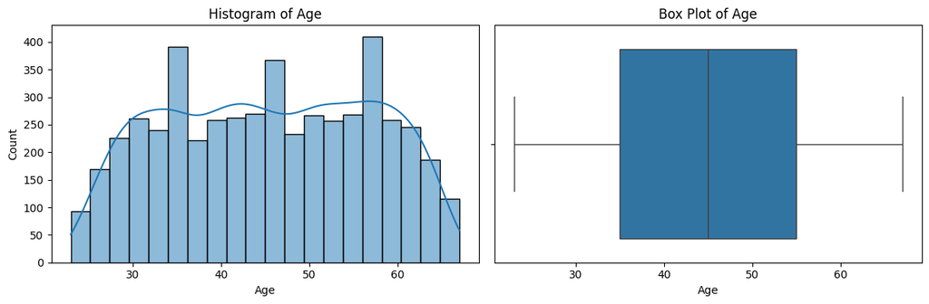

```python
plot_univariate(df, 'Age')
```

- Ages in this dataset cover a fairly broad range of working-age adults.
- The center of the distribution (median ~45) indicates that the dataset tends to cluster around middle-age.
- No glaring anomalies or extreme outliers in Age—it’s a fairly continuous spread within a normal working range.

#### Experience

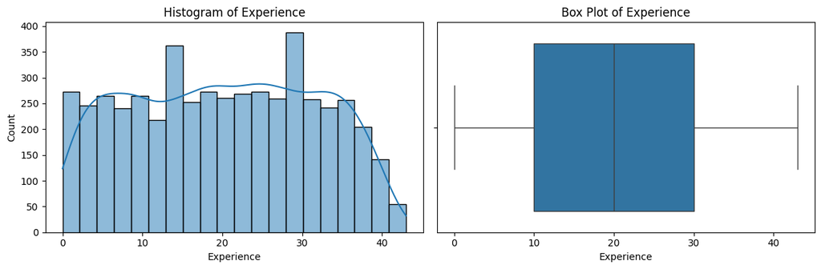

```python
plot_univariate(df, 'Experience')
```

- Experience in this dataset cover a fairly broad range of freshers to seniors.
- The center of the distribution (median ~20) meaning half the dataset has ≤20 years of experience and half has more.
- The majority of them has the 10 to 30 years of experiece.

#### Income

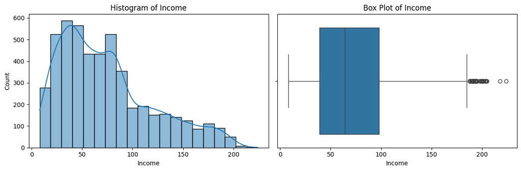

```python
plot_univariate(df, 'Income')
```

#### ZIPCode

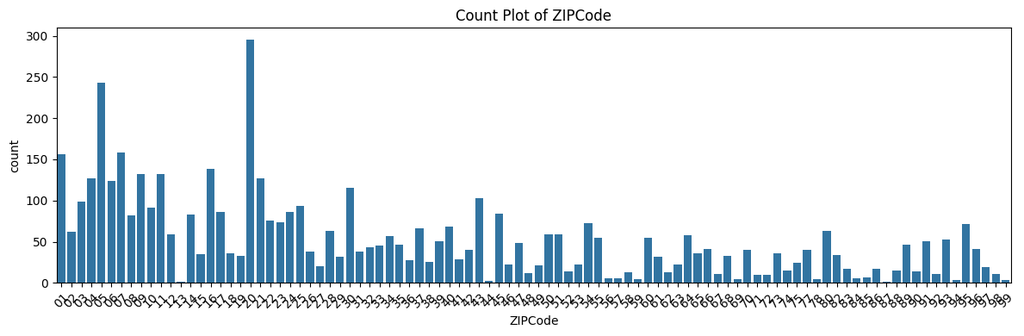

```python
plot_univariate(df, 'ZIPCode', kde=False, plot_piechart=False)
```

- Some ZIP codes appear much more frequently than others, indicating that the data is not uniformly distributed across all possible ZIP codes.
- I might use this to give recomendations for area based marketing.

#### Family

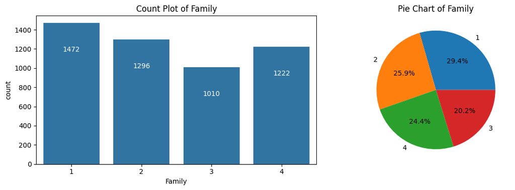

```python
plot_univariate(df, 'Family', show_count=True)
```

#### CCAvg

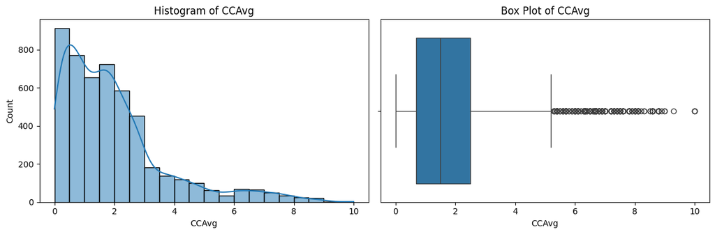

```python
plot_univariate(df, 'CCAvg')
```

#### Education

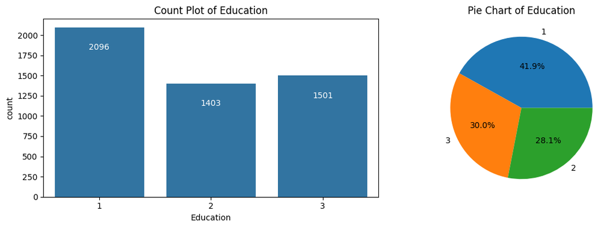

```python
plot_univariate(df, 'Education', show_count=True)
```

#### Mortgage

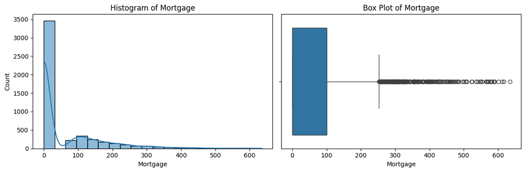

```python
plot_univariate(df, 'Mortgage')
```

- This indicates that most individuals in the dataset do not carry a mortgage (or have a relatively small one), while a smaller group has significantly larger mortgage amounts.

**Noticeable Patterns**

- Over 3,000 entries are at Mortgage = 0, making it by far the most common value.
- Past 50–100, the frequencies drop sharply, but there are still numerous observations spread across higher mortgage amounts.

**Outliers**

- In the box plot, everything beyond roughly 250 is considered an outlier, though those may be perfectly valid values for individuals with sizable mortgages.
- Because of so many zeros, even moderate mortgage values appear as outliers.

#### Personal Loan

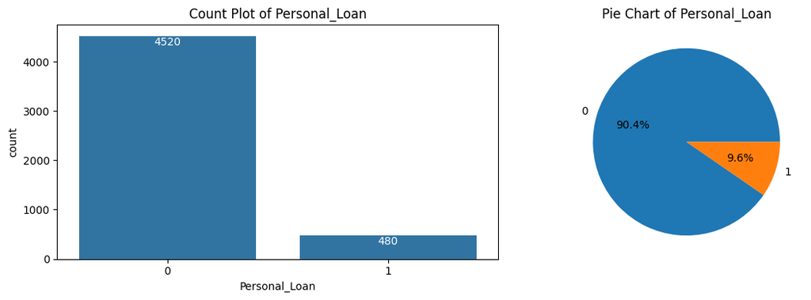

```python
plot_univariate(df, 'Personal_Loan', show_count=True)
```

- About 90.4% of the observations do not have a personal loan (0), while around 9.6% have (1).
- This indicates that the dataset is somewhat imbalanced for this feature, with fewer individuals having a personal loan compared to those who do not.

#### Securites Account

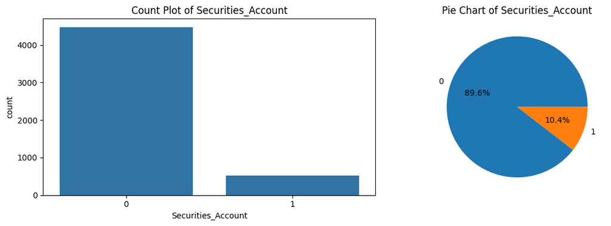

```python
plot_univariate(df, 'Securities_Account')
```

- About 89.6% of the observations do not hold a securities account (0), while around 10.4% do (1).
- This indicates that the dataset is somewhat imbalanced for this feature, with fewer individuals having a securities account compared to those who do not.

#### CD Account

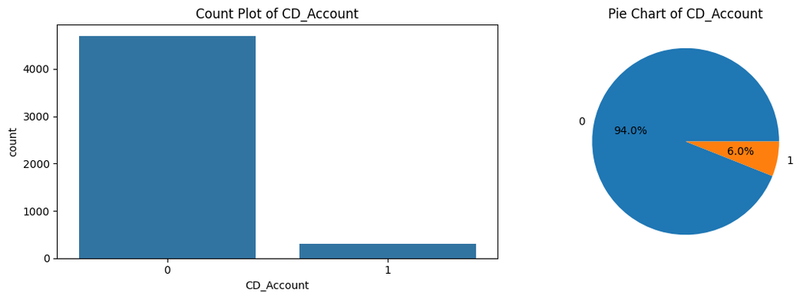

```python
plot_univariate(df, 'CD_Account')
```

- About 94% of the observations do not have a CD account (0), while around 6% do (1).
- This indicates that the dataset is somewhat imbalanced for this feature, with fewer individuals having a CD account compared to those who do not.

#### Online

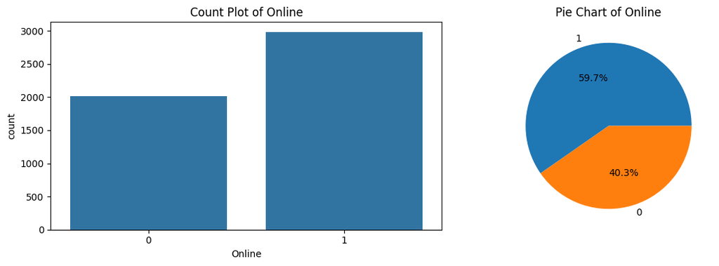

```python
plot_univariate(df, 'Online')
```

- Around 60% of the dataset is use internet banking (1), and 40% remains offline (0)
- Users who transact online might exhibit different spending or borrowing patterns compared to those who only use in-store services.

#### CreditCard

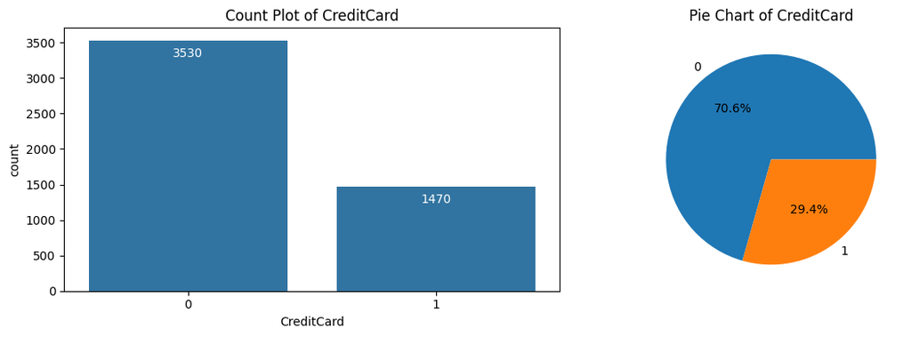

```python
plot_univariate(df, 'CreditCard', show_count=True)
```

- About 70.6% of customers (3,530 observations) do not use another bank’s credit card.
- Roughly 29.4% (1,470 observations) do have a credit card from a different bank.
- This feature may be important if we’re trying to understand competitive behavior or loyalty. People who already have another bank’s credit card might behave differently when offered new financial products (e.g., personal loans) compared to those who do not.

### Multivariate

#### Helper Function

```python
def plot_multivariate_all(dataset, col_x, col_y, figsize=(12,4)):
    """
    Plot multiple comparisons between two columns in a dataset,
    with the choice of plots depending on the data types of the columns.

    Behavior:
        1. Numeric vs. Numeric (both columns are numeric):
           - Scatter Plot
           - 2D KDE Plot

        2. Numeric vs. Categorical:
           - Box Plot
           - Violin Plot

        3. Categorical vs. Numeric:
           - Box Plot
           - Violin Plot

        4. Categorical vs. Categorical:
           - Grouped Bar Plot for counts

    Args:
        dataset (pd.DataFrame): The input DataFrame containing the data.
        col_x (str): The name of the first column (x-axis).
        col_y (str): The name of the second column (y-axis).
        figsize (tuple, optional): The figure size (width, height) for the plots.
                                   Defaults to (12, 4).

    Returns:
        None. Displays the generated plots.
    """

    # Determine data types
    x_dtype = dataset[col_x].dtype
    y_dtype = dataset[col_y].dtype

    # Check if columns are numeric (int, float, complex)
    x_is_num = x_dtype.kind in 'iufc'
    y_is_num = y_dtype.kind in 'iufc'

    if x_is_num and y_is_num:
        # Both columns are numeric: scatter plot and 2D KDE
        fig, axes = plt.subplots(1, 2, figsize=figsize)

        # Scatter Plot
        sns.scatterplot(x=col_x, y=col_y, data=dataset, ax=axes[0])
        axes[0].set_title(f'Scatter: {col_x} vs. {col_y}')

        # 2D KDE Plot
        sns.kdeplot(x=dataset[col_x], y=dataset[col_y], fill=True, cmap='Blues', ax=axes[1])
        axes[1].set_title(f'KDE: {col_x} vs. {col_y}')

        plt.tight_layout()
        plt.show()

    elif x_is_num and not y_is_num:
        # X is numeric, Y is categorical: box plot and violin plot
        fig, axes = plt.subplots(1, 2, figsize=figsize)

        # Box Plot
        sns.boxplot(x=col_y, y=col_x, data=dataset, ax=axes[0])
        axes[0].set_title(f'Box Plot: {col_x} by {col_y}')

        # Violin Plot
        sns.violinplot(x=col_y, y=col_x, data=dataset, ax=axes[1])
        axes[1].set_title(f'Violin Plot: {col_x} by {col_y}')

        plt.tight_layout()
        plt.show()

    elif not x_is_num and y_is_num:
        # X is categorical, Y is numeric: box plot and violin plot (flipped axes)
        fig, axes = plt.subplots(1, 2, figsize=figsize)

        # Box Plot
        sns.boxplot(x=col_x, y=col_y, data=dataset, ax=axes[0])
        axes[0].set_title(f'Box Plot: {col_y} by {col_x}')

        # Violin Plot
        sns.violinplot(x=col_x, y=col_y, data=dataset, ax=axes[1])
        axes[1].set_title(f'Violin Plot: {col_y} by {col_x}')

        plt.tight_layout()
        plt.show()

    else:
        # Both columns are categorical: grouped bar plot
        # Create a temporary table of counts
        ct = dataset.groupby([col_x, col_y], observed=False).size().reset_index(name='count')

        plt.figure(figsize=figsize)
        sns.barplot(x=col_x, y='count', hue=col_y, data=ct)
        plt.title(f'Count by {col_x} and {col_y}')
        plt.xticks(rotation=45)
        plt.tight_layout()
        plt.show()
```

#### Correlation (Numerical)

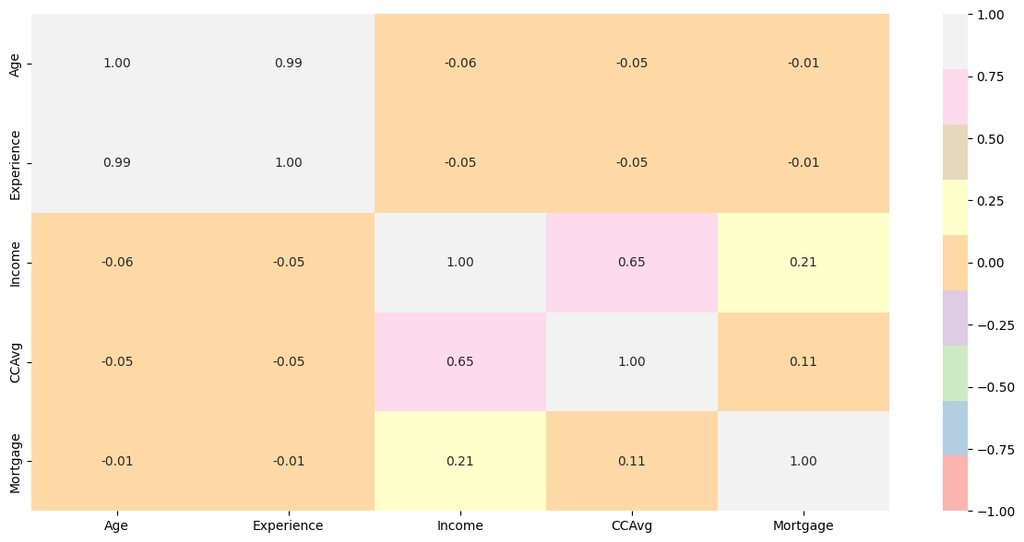

```python
plt.figure(figsize=(15, 7))
sns.heatmap(df.corr(numeric_only=True), annot=True, vmin=-1, vmax=1, fmt=".2f", cmap="Pastel1")
plt.show()
```

- The strong positive correlation between **Age** and **Experience** suggests collinearity. Including both in a model might be redundant.
- **Income** and **CCAvg** exhibit the strongest meaningful relationship, implying income could be a good predictor of spending behavior.

#### Correlation (Categorical)

```python
from scipy.stats import chi2_contingency

def calculate_cramers_v(x, y):
    """
    Calculate Cramér’s V for two categorical pandas Series x and y.

    Parameters:
    - x: pandas Series, first categorical variable
    - y: pandas Series, second categorical variable

    Returns:
    - Cramér’s V value, a measure of association between the two variables.
    """
    # Create a confusion matrix (contingency table) for the two variables
    confusion_matrix = pd.crosstab(x, y)

    # Perform the chi-squared test on the contingency table
    chi2, p, dof, expected = chi2_contingency(confusion_matrix)

    # Calculate the total number of observations
    n = confusion_matrix.sum().sum()

    # Determine the number of rows (r) and columns (k) in the table
    r, k = confusion_matrix.shape

    # Calculate and return Cramér’s V
    return np.sqrt((chi2 / n) / (min(k - 1, r - 1)))


def get_sorted_cramers_v_scores(dataframe, target_column):
    """
    Calculate and return sorted Cramér’s V scores for all features against the target column.

    Parameters:
    - dataframe: pandas DataFrame, the dataset containing features and target variable
    - target_column: str, name of the target column to compare other features against

    Returns:
    - A sorted pandas DataFrame of features and their corresponding Cramér’s V scores in descending order.
    """
    scores = {}

    # Calculate Cramér’s V for each feature against the target variable
    for column in dataframe.columns:
        if column != target_column:  # Skip the target column itself
            scores[column] = calculate_cramers_v(dataframe[column], dataframe[target_column])

    # Convert the scores dictionary to a DataFrame
    scores_df = pd.DataFrame(scores.items(), columns=['Feature', 'Cramér’s V Score'])

    # Sort the DataFrame by the scores in descending order
    sorted_scores_df = scores_df.sort_values(by='Cramér’s V Score', ascending=False).reset_index(drop=True)

    return sorted_scores_df


# Get sorted Cramér’s V scores for all features against 'Personal_Loan'
sorted_cramers_v_scores = get_sorted_cramers_v_scores(df, 'Personal_Loan')

# Display the sorted scores
print("Sorted Cramér’s V Scores:")
print(sorted_cramers_v_scores)
```

```
Sorted Cramér’s V Scores:
               Feature  Cramér’s V Score
0               Income          0.595523
1                CCAvg          0.565880
2             Mortgage          0.395316
3           CD_Account          0.314930
4              ZIPCode          0.156371
5            Education          0.149158
6                  Age          0.105063
7           Experience          0.083577
8               Family          0.077040
9   Securities_Account          0.020844
10              Online          0.005586
11          CreditCard          0.002056
```

1. Personal_Loan vs Income (0.596) and Personal_Loan vs CCAvg (0.566):
- These scores indicate a strong relationship between personal loan uptake and these variables:
  - Income: Customers with higher income levels are significantly more likely to take personal loans.
  - CCAvg (Average Monthly Credit Card Spending): Customers who spend more on credit cards are strongly associated with personal loan uptake, suggesting comfort with credit-based products.
2. Personal_Loan vs Mortgage (0.395):
- This indicates a moderate-to-strong association. Customers with mortgages might exhibit distinct behavior, either positively or negatively, toward personal loan uptake, depending on the financial strategies they prefer.
3. Personal_Loan vs CD_Account (0.315):
- This remains a moderate-to-strong relationship. Customers who open a Certificate of Deposit (CD) account are associated with personal loan uptake. The relationship might suggest that these customers are more financially active or seek additional financial products.
4. Personal_Loan vs ZIPCode (0.156) and Personal_Loan vs Education (0.149):
- Both variables show a weak-to-moderate relationship:
  - ZIPCode likely reflects regional effects or socio-economic differences influencing personal loan uptake.
  - Education Level (1=Undergrad, 2=Graduate, 3=Professional) suggests that customers with higher education levels may have a slightly greater likelihood of taking personal loans.
5. Personal_Loan vs Age (0.105):
- This indicates a weak association, suggesting that age has a minor impact on the likelihood of taking a personal loan.
6. Personal_Loan vs Experience (0.084) and Personal_Loan vs Family (0.077):
- These fall into the very weak-to-weak category, meaning these factors may have some influence but are not strong predictors of personal loan uptake.
7. Personal_Loan vs Securities_Account (0.021), Online (0.0056), and CreditCard (0.002):
- These variables show extremely weak associations (close to zero). Having a securities account, being an online banking user, or owning another bank’s credit card does not meaningfully correlate with personal loan uptake.

#### Age vs Personal Loan

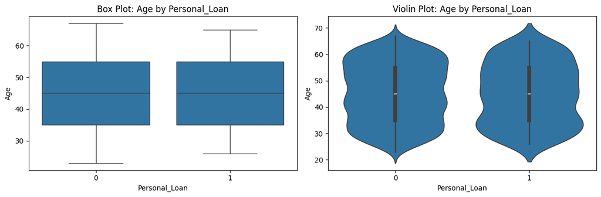

```python
plot_multivariate_all(df, 'Age', 'Personal_Loan')
```

Age does not appear to be a strong differentiator between customers who take personal loans and those who do not. The distribution of age is nearly identical across both groups

#### Experience vs Personal Loan

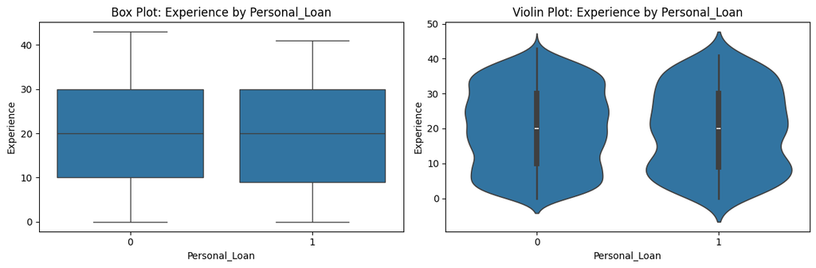

```python
plot_multivariate_all(df, 'Experience', 'Personal_Loan')
```

Age and Experience has strong correlation so theeir plot is same here

#### Income vs Personal Loan

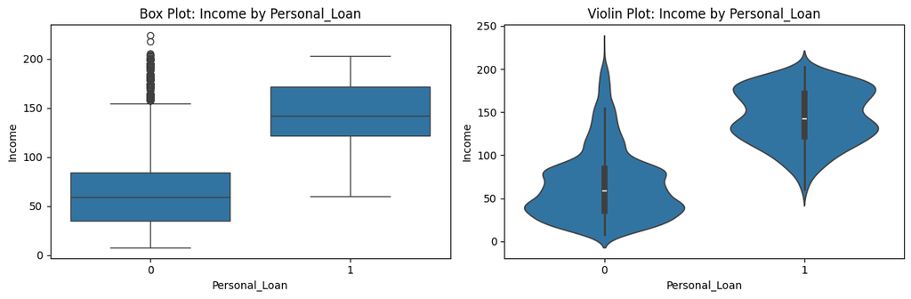

```python
plot_multivariate_all(df, 'Income', 'Personal_Loan')
```

- Income is a strong differentiator between customers who take personal loans and those who don’t. Higher-income customers are much more likely to take a personal loan.
- This suggests that income might be a highly predictive feature in determining personal loan uptake.

#### ZIPCode vs Personal Loan

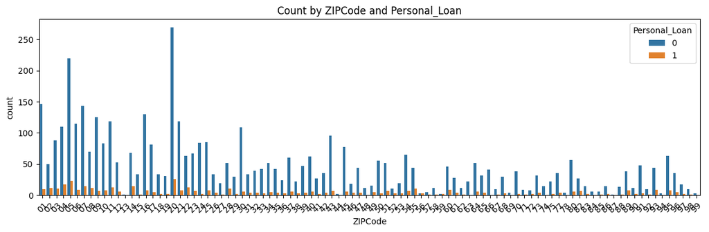

```python
plot_multivariate_all(df, 'ZIPCode', 'Personal_Loan');
```

Some ZIP codes have higher overall counts (e.g., the tall blue bars), but this could be due to population density in those areas rather than any specific trend related to personal loans.

#### Education vs Personal Loan

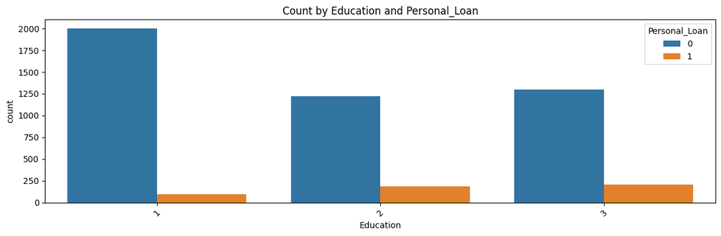

```python
plot_multivariate_all(df, 'Education', 'Personal_Loan');
```

- Education Level is a meaningful feature for understanding personal loan uptake. Higher education levels are associated with a greater proportion of loans.
- Level 3 (Advanced/Professional) shows the strongest relationship with personal loans, making it a key predictor in modeling.

#### Mortgage vs Personal Loan

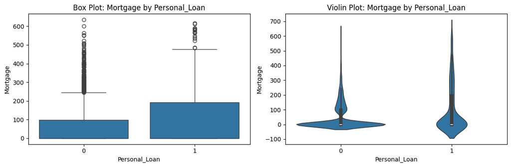

```python
plot_multivariate_all(df, 'Mortgage', 'Personal_Loan');
```

- The density of Violin plot for Personal_Loan = 0 is concentrated at 0, with a narrow spread for higher mortgage values. This highlights that most customers without personal loans tend to have lower or no mortgages.
- Customers with personal loans (Personal_Loan = 1) generally have higher mortgages compared to those without loans

#### Securities Account vs Personal Loan

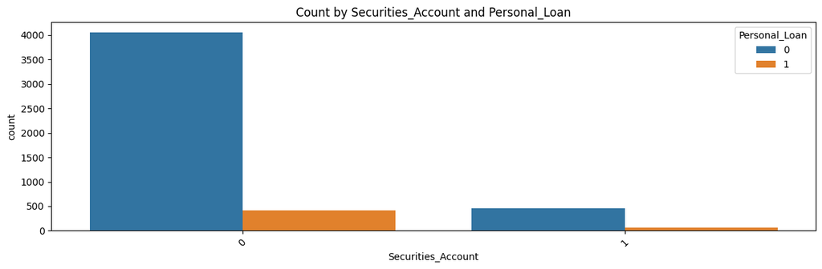

```python
plot_multivariate_all(df, 'Securities_Account', 'Personal_Loan');
```

- Securities_Account has a minimal relationship with Personal_Loan. The counts of Personal_Loan = 1 are low regardless of whether the customer has a securities account or not.
- This aligns with earlier findings (e.g., Cramér’s V score), where the association between Securities_Account and Personal_Loan was weak.

#### CD Account vs Personal Loan

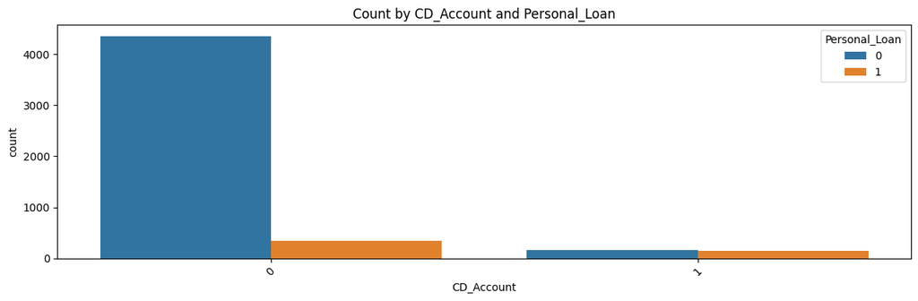

```python
plot_multivariate_all(df, 'CD_Account', 'Personal_Loan');
```

- Customers with CD accounts are more likely to accept personal loans compared to those without.
- This aligns with the earlier Cramér’s V score, where CD_Account showed a relatively strong relationship with Personal_Loan.

#### Online vs Personal Loan

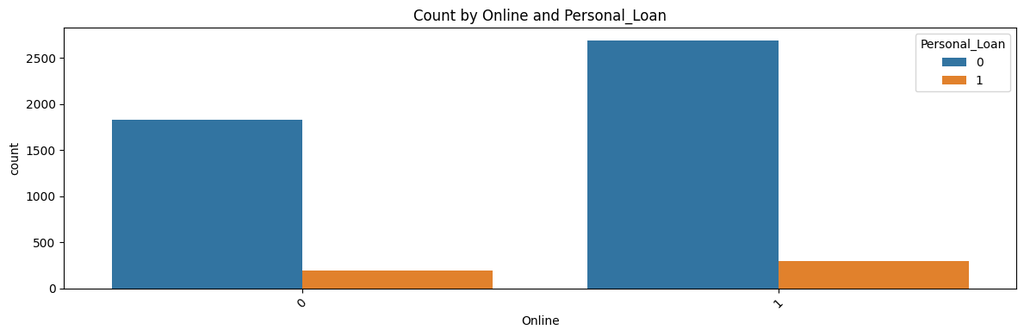

```python
plot_multivariate_all(df, 'Online', 'Personal_Loan');
```

- Online has a minimal relationship with Personal_Loan. The counts of Personal_Loan = 1 are low regardless of whether the customer use internet banking or do not.
- This aligns with earlier findings (e.g., Cramér’s V score), where the association between Online and Personal_Loan was weak.

#### Credit Card vs Personal Loan

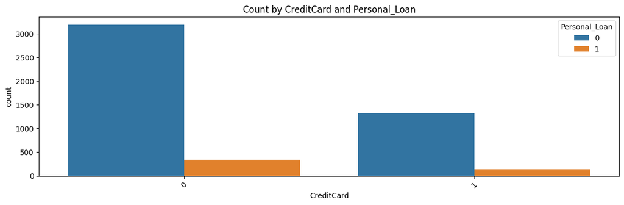

```python
plot_multivariate_all(df, 'CreditCard', 'Personal_Loan');
```

- CreditCard has a minimal relationship with Personal_Loan. The counts of Personal_Loan = 1 are low regardless of whether the customer has another bank crediCard or not.
- This aligns with earlier findings (e.g., Cramér’s V score), where the association between crediCard and Personal_Loan was weak.

## Data Preprocessing

```python
# Feature sets for two scenarios:
# 1. Dropping 'Experience' due to its strong correlation with 'Age' (X_with_dropped_experience)
# 2. Keeping 'Experience' to observe its effect (X_with_experience)

# Feature set where 'Experience' is dropped to avoid multicollinearity with 'Age'
X_with_dropped_experience = df.drop(["Personal_Loan", "Experience"], axis=1)

# Feature set where 'Experience' is kept for comparison
X_with_experience = df.drop(["Personal_Loan"], axis=1)

# Extracting the target variable 'Personal_Loan' into y
y = df['Personal_Loan']

# Encoding categorical variables ('ZIPCode', 'Family', 'Education') into dummy/one-hot encoded variables
# 'drop_first=True' avoids the dummy variable trap by removing the first category in each feature
X_with_experience = pd.get_dummies(X_with_experience, columns=['ZIPCode', 'Family', 'Education'], drop_first=True)
X_with_dropped_experience = pd.get_dummies(X_with_dropped_experience, columns=['ZIPCode', 'Family', 'Education'], drop_first=True)

# Ensuring all features are converted to float type for consistency in modeling
X_with_experience = X_with_experience.astype(float)
X_with_dropped_experience = X_with_dropped_experience.astype(float)
```

```python
# Splitting the feature set with 'Experience' retained into training and testing sets
# 70% of the data is used for training, and 30% is used for testing
# 'random_state=42' ensures consistent and reproducible splits
X_train_with_experience, X_test_with_experience, y_train, y_test = train_test_split(
    X_with_experience, y, train_size=0.7, random_state=42
)

# Splitting the feature set with 'Experience' dropped into training and testing sets
X_train_with_dropped_experience, X_test_with_dropped_experience, y_train, y_test = train_test_split(
    X_with_dropped_experience, y, train_size=0.7, random_state=42
)
```

```python
# Get the list of feature names from the feature set with 'Experience' retained
feature_names_with_experience = X_train_with_experience.columns.tolist()

# Get the list of feature names from the feature set with 'Experience' dropped
feature_names_with_dropped_experience = X_train_with_dropped_experience.columns.tolist()
```

#### Detecting Outliers

```python
# Calculating the first quartile (Q1) for all numerical features in the training set
# Only columns with data types 'int64' and 'float64' are included
Q1_with_experience = X_train_with_experience.select_dtypes(include=['int64', 'float64']).quantile(0.25)
Q1_with_dropped_experience = X_train_with_dropped_experience.select_dtypes(include=['int64', 'float64']).quantile(0.25)

# Calculating the third quartile (Q3) for all numerical features in the training set
Q3_with_experience = X_train_with_experience.select_dtypes(include=['int64', 'float64']).quantile(0.75)
Q3_with_dropped_experience = X_train_with_dropped_experience.select_dtypes(include=['int64', 'float64']).quantile(0.75)

# Calculating the interquartile range (IQR), which measures the spread of the middle 50% of the data
IQR_with_experience = Q3_with_experience - Q1_with_experience
IQR_with_dropped_experience = Q3_with_dropped_experience - Q1_with_dropped_experience

# Determining the lower boundary for outliers using the formula Q1 - 1.5 * IQR
lower_edge_with_experience = Q1_with_experience - 1.5 * IQR_with_experience
lower_edge_with_dropped_experience = Q1_with_dropped_experience - 1.5 * IQR_with_dropped_experience

# Determining the upper boundary for outliers using the formula Q3 + 1.5 * IQR
upper_edge_with_experience = Q3_with_experience + 1.5 * IQR_with_experience
upper_edge_with_dropped_experience = Q3_with_dropped_experience + 1.5 * IQR_with_dropped_experience
```

```python
# Identifying outliers below the lower boundary for each numerical feature in the training set with 'Experience' retained
# 'select_dtypes' ensures only numeric columns ('int64', 'float64') are considered
# For each feature, checks where values are less than the lower_edge threshold
# 'sum()' counts the number of such outliers for each feature
# Dividing by the total number of rows in X_train_with_experience and multiplying by 100 gives the percentage of rows with values below the lower boundary
outliers_below_lower_edge_with_experience = (X_train_with_experience.select_dtypes(include=['int64', 'float64']) < lower_edge_with_experience).sum() / len(X_train_with_experience) * 100
print("Identifying outliers below the lower boundary for each numerical feature in the training set with 'Experience' retained")
print(outliers_below_lower_edge_with_experience[outliers_below_lower_edge_with_experience > 0])
# Identifying outliers below the lower boundary for each numerical feature in the training set with 'Experience' dropped
outliers_below_lower_edge_with_dropped_experience = (X_train_with_dropped_experience.select_dtypes(include=['int64', 'float64']) < lower_edge_with_dropped_experience).sum() / len(X_train_with_dropped_experience) * 100
print("\nIdentifying outliers below the lower boundary for each numerical feature in the training set with 'Experience' dropped")
print(outliers_below_lower_edge_with_dropped_experience[outliers_below_lower_edge_with_dropped_experience > 0])
```

```
Identifying outliers below the lower boundary for each numerical feature in the training set with 'Experience' retained
Series([], dtype: float64)

Identifying outliers below the lower boundary for each numerical feature in the training set with 'Experience' dropped
Series([], dtype: float64)
```

```python
# Identifying outliers above the upper boundary for each numerical feature in the training set with 'Experience' retained
# 'select_dtypes' ensures only numeric columns ('int64', 'float64') are considered
# For each feature, checks where values are greater than the upper_edge threshold
# 'sum()' counts the total number of such outliers for each feature
# Dividing by the total number of rows in X_train_with_experience and multiplying by 100 gives the percentage of rows with values above the upper boundary
outliers_above_upper_edge_with_experience = (X_train_with_experience.select_dtypes(include=['int64', 'float64']) > upper_edge_with_experience).sum() / len(X_train_with_experience) * 100
print("Identifying outliers above the upper boundary for each numerical feature in the training set with 'Experience' retained")
print(outliers_above_upper_edge_with_experience[outliers_above_upper_edge_with_experience > 5])

# Identifying outliers above the upper boundary for each numerical feature in the training set with 'Experience' dropped
outliers_above_upper_edge_with_dropped_experience = (X_train_with_dropped_experience.select_dtypes(include=['int64', 'float64']) > upper_edge_with_dropped_experience).sum() / len(X_train_with_dropped_experience) * 100
print("\nIdentifying outliers above the upper boundary for each numerical feature in the training set with 'Experience' dropped")
print(outliers_above_upper_edge_with_dropped_experience[outliers_above_upper_edge_with_dropped_experience > 5])
```

```
Identifying outliers above the upper boundary for each numerical feature in the training set with 'Experience' retained
CCAvg                  6.514286
Mortgage               6.200000
Securities_Account    10.342857
CD_Account             6.028571
ZIPCode_20             6.057143
Family_3              20.171429
Family_4              24.142857
dtype: float64

Identifying outliers above the upper boundary for each numerical feature in the training set with 'Experience' dropped
CCAvg                  6.514286
Mortgage               6.200000
Securities_Account    10.342857
CD_Account             6.028571
ZIPCode_20             6.057143
Family_3              20.171429
Family_4              24.142857
dtype: float64
```

The outilers are normal based on the datset and features, so I am not gonna treat them and keep them as it is.

## Model Building

### Model Evaluation Criterion

```python
def model_metrics_overview(estimator, predictors, targets):
    """
    Evaluates the performance of a trained model using common classification metrics.

    Parameters:
    ----------
    estimator : model object
        A trained machine learning model with a `predict` method.
    predictors : array-like or DataFrame
        The feature set (X) to be used for prediction.
    targets : array-like or Series
        The true target values (y) for evaluation.

    Returns:
    -------
    metrics : DataFrame
        A DataFrame containing Accuracy, Recall, Precision, and F1 Score.
    """
    # Generate predictions using the trained model
    predicts = estimator.predict(predictors)

    # Calculate classification metrics
    accuracy = accuracy_score(targets, predicts)  # Proportion of correct predictions
    recall = recall_score(targets, predicts)      # Proportion of true positives identified
    precision = precision_score(targets, predicts)  # Proportion of predicted positives that are correct
    f1 = f1_score(targets, predicts)              # Harmonic mean of precision and recall

    # Create a DataFrame to store the calculated metrics
    metrics = pd.DataFrame(
        {
            "Accuracy": accuracy,
            "Recall": recall,
            "Precision": precision,
            "F1": f1,
        },
        index=[0],  # Single row DataFrame for metrics
    )

    # Return the DataFrame containing the metrics
    return metrics
```

```python
def confusion_matrix_overview(estimator, predictors, targets):
    """
    Generates a confusion matrix heatmap with counts, percentages, and TP/FP/TN/FN labels for a binary classification model.

    Parameters:
    ----------
    estimator : model object
        A trained machine learning model with a `predict` method.
    predictors : array-like or DataFrame
        The feature set (X) to be used for prediction.
    targets : array-like or Series
        The true target values (y) for evaluation.

    Returns:
    -------
    None
        Displays a heatmap of the confusion matrix with counts, percentages, and section labels.
    """
    # Generate predictions using the trained model
    predicts = estimator.predict(predictors)

    # Compute the confusion matrix
    cm = confusion_matrix(targets, predicts)

    # Labels for the sections of the confusion matrix
    section_labels = np.array([["TN", "FP"], ["FN", "TP"]])

    # Format the matrix to include counts, percentages, and section labels
    total = cm.sum()  # Total number of samples
    labels = np.asarray(
        [
            f"{label}\n{count}\n{count/total:.2%}"  # Format as "Label\nCount\nPercentage"
            for label, count in zip(section_labels.flatten(), cm.flatten())
        ]
    ).reshape(2, 2)  # Reshape into the same dimensions as the confusion matrix

    # Create the heatmap
    plt.figure(figsize=(4, 3))
    sns.heatmap(
        cm,
        annot=labels,      # Add counts, percentages, and section labels as annotations
        fmt="",            # No additional formatting for annotations
        cmap="Blues",      # Use a visually appealing color map
        cbar=False,        # Hide the color bar for simplicity
        annot_kws={"size": 10},  # Customize annotation text size
    )

    # Add labels, title, and improve layout
    plt.ylabel("True Label", fontsize=10)
    plt.xlabel("Predicted Label", fontsize=10)
    plt.title("Confusion Matrix Overview", fontsize=12)
    plt.xticks(ticks=[0.5, 1.5], labels=["0 (Negative)", "1 (Positive)"], fontsize=8)
    plt.yticks(ticks=[0.5, 1.5], labels=["0 (Negative)", "1 (Positive)"], fontsize=8)
    plt.tight_layout()  # Adjust layout to prevent overlapping
    plt.show()
```

```python
def filter_important_features(model, feature_names):
    """
    Filters and returns features with importance greater than 0 from a trained Decision Tree model.

    Parameters:
    - model: Trained Decision Tree model (e.g., DecisionTreeClassifier or DecisionTreeRegressor).
    - feature_names: List of feature names corresponding to the training data.

    Returns:
    - A pandas DataFrame containing features with importance > 0, sorted in descending order of importance.
    """
    # Extract feature importance scores from the trained model
    feature_importances = model.feature_importances_

    # Map feature names to their corresponding importance scores in a DataFrame
    feature_importance_df = pd.DataFrame({
        'Feature': feature_names,  # Use the provided feature names
        'Importance': feature_importances  # Importance scores from the model
    })

    # Filter features with importance greater than 0
    filtered_features_df = feature_importance_df[feature_importance_df['Importance'] > 0]

    # Sort the filtered features by importance in descending order
    filtered_features_df = filtered_features_df.sort_values(by='Importance', ascending=False).reset_index(drop=True)

    # Return the filtered and sorted DataFrame
    return filtered_features_df
```

### Model Building

#### Train model with **Experience**

```python
# Initialize the Decision Tree Classifier
# 'random_state=42' ensures reproducibility of the model's behavior
decision_tree_with_experience = DecisionTreeClassifier(random_state=42)

# Train the Decision Tree Classifier on the training dataset with 'Experience' retained
# The model learns the relationship between features (X_train_with_experience) and target (y_train)
decision_tree_with_experience.fit(X_train_with_experience, y_train)
```

```
DecisionTreeClassifier(random_state=42)
```

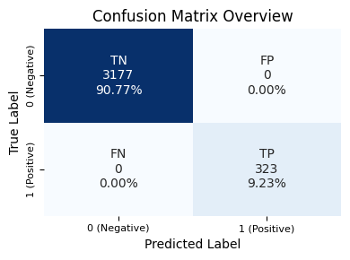

```python
# Generating a confusion matrix overview for the Decision Tree model trained with 'Experience' retained
# This evaluates the model's predictions on the training dataset (X_train_with_experience, y_train)
# Displays a heatmap with the confusion matrix values and percentages
confusion_matrix_overview(decision_tree_with_experience, X_train_with_experience, y_train)
```

```python
# Evaluating the performance of the Decision Tree model trained with 'Experience' retained on the training dataset
# The function calculates key classification metrics: Accuracy, Recall, Precision, and F1 Score
# Metrics are returned as a DataFrame for easier visualization and analysis
decision_tree_train_metrics_with_experience = model_metrics_overview(
    decision_tree_with_experience, X_train_with_experience, y_train
)

# Displaying the calculated metrics for the Decision Tree model with 'Experience' retained
print("Displaying the calculated metrics for the Decision Tree model with 'Experience' retained")
decision_tree_train_metrics_with_experience
```

```
Displaying the calculated metrics for the Decision Tree model with 'Experience' retained
```

|  | Accuracy | Recall | Precision | F1 |
| --- | --- | --- | --- | --- |
| 0 | 1.0 | 1.0 | 1.0 | 1.0 |

```python
# Evaluating the performance of the Decision Tree model trained with 'Experience' retained on the test dataset
decision_tree_test_metrics_with_experience = model_metrics_overview(
    decision_tree_with_experience, X_test_with_experience, y_test
)

# Displaying the calculated metrics for the Decision Tree model with 'Experience' retained
print("Displaying the calculated metrics for the Decision Tree model with 'Experience' retained")
decision_tree_test_metrics_with_experience
```

```
Displaying the calculated metrics for the Decision Tree model with 'Experience' retained
```

|  | Accuracy | Recall | Precision | F1 |
| --- | --- | --- | --- | --- |
| 0 | 0.976667 | 0.859873 | 0.912162 | 0.885246 |

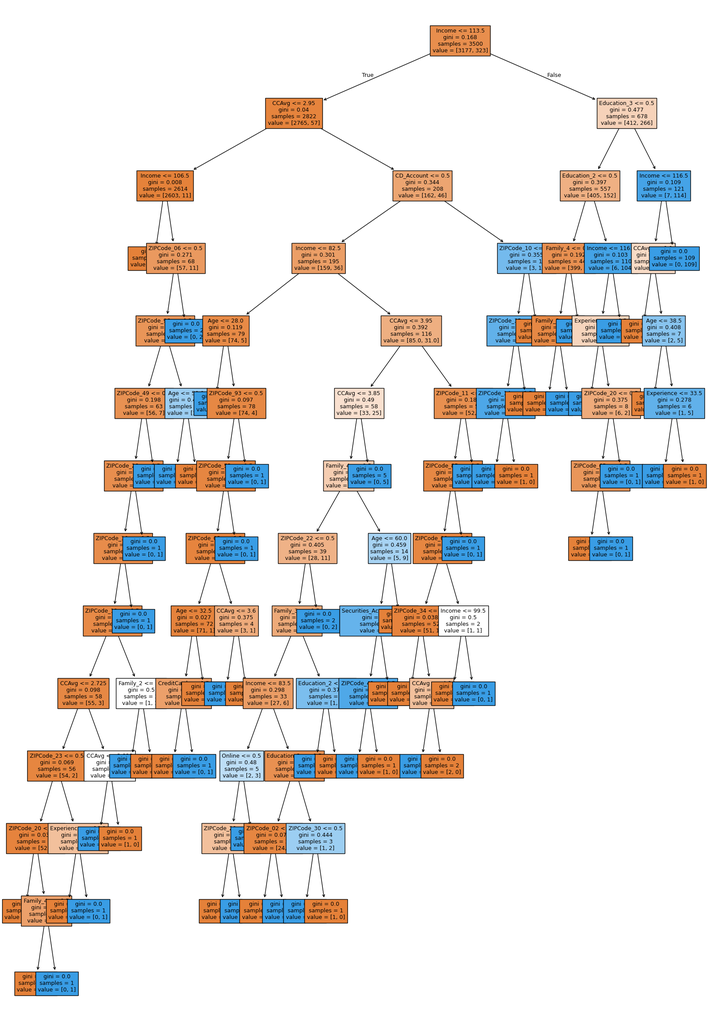

```python
# Setting the figure size for the Decision Tree visualization
plt.figure(figsize=(20, 30))

# Visualizing the trained Decision Tree model
# 'plot_tree' generates a graphical representation of the decision tree
# - feature_names: Names of the features used in the splits
# - filled=True: Adds color to the nodes for easier interpretation
# - fontsize=9: Adjusts font size for readability
decision_tree_visual = tree.plot_tree(
    decision_tree_with_experience,
    feature_names=feature_names_with_experience,
    filled=True,
    fontsize=9,
    node_ids=False,
    class_names=None,  # You can add target class names if available
)

# Ensuring arrows between nodes are properly formatted
# Some arrows may lack properties, so we explicitly set edge color and line width
for node in decision_tree_visual:
    arrow = node.arrow_patch
    if arrow is not None:
        arrow.set_edgecolor("black")  # Set arrow edge color to black
        arrow.set_linewidth(1)       # Set arrow line width for better visibility

# Displaying the Decision Tree visualization
plt.show()
```

```python
# Printing a text-based representation of the trained Decision Tree model
# 'export_text' generates a text summary of the tree structure:
# - feature_names: Names of the features used in the splits
# - show_weights=True: Displays the number of samples and class distribution at each node
tree_structure = tree.export_text(decision_tree_with_experience, feature_names=feature_names_with_experience, show_weights=True)

# Printing the tree structure for review
print(tree_structure)
```

```
|--- Income <= 113.50
|   |--- CCAvg <= 2.95
|   |   |--- Income <= 106.50
|   |   |   |--- weights: [2546.00, 0.00] class: 0
|   |   |--- Income >  106.50
|   |   |   |--- ZIPCode_06 <= 0.50
|   |   |   |   |--- ZIPCode_96 <= 0.50
|   |   |   |   |   |--- ZIPCode_49 <= 0.50
|   |   |   |   |   |   |--- ZIPCode_28 <= 0.50
|   |   |   |   |   |   |   |--- ZIPCode_10 <= 0.50
|   |   |   |   |   |   |   |   |--- ZIPCode_11 <= 0.50
|   |   |   |   |   |   |   |   |   |--- CCAvg <= 2.73
|   |   |   |   |   |   |   |   |   |   |--- ZIPCode_23 <= 0.50
|   |   |   |   |   |   |   |   |   |   |   |--- truncated branch of depth 3
|   |   |   |   |   |   |   |   |   |   |--- ZIPCode_23 >  0.50
|   |   |   |   |   |   |   |   |   |   |   |--- truncated branch of depth 2
|   |   |   |   |   |   |   |   |   |--- CCAvg >  2.73
|   |   |   |   |   |   |   |   |   |   |--- CCAvg <= 2.83
|   |   |   |   |   |   |   |   |   |   |   |--- weights: [0.00, 1.00] class: 1
|   |   |   |   |   |   |   |   |   |   |--- CCAvg >  2.83
|   |   |   |   |   |   |   |   |   |   |   |--- weights: [1.00, 0.00] class: 0
|   |   |   |   |   |   |   |   |--- ZIPCode_11 >  0.50
|   |   |   |   |   |   |   |   |   |--- Family_2 <= 0.50
|   |   |   |   |   |   |   |   |   |   |--- weights: [0.00, 1.00] class: 1
|   |   |   |   |   |   |   |   |   |--- Family_2 >  0.50
|   |   |   |   |   |   |   |   |   |   |--- weights: [1.00, 0.00] class: 0
|   |   |   |   |   |   |   |--- ZIPCode_10 >  0.50
|   |   |   |   |   |   |   |   |--- weights: [0.00, 1.00] class: 1
|   |   |   |   |   |   |--- ZIPCode_28 >  0.50
|   |   |   |   |   |   |   |--- weights: [0.00, 1.00] class: 1
|   |   |   |   |   |--- ZIPCode_49 >  0.50
|   |   |   |   |   |   |--- weights: [0.00, 1.00] class: 1
|   |   |   |   |--- ZIPCode_96 >  0.50
|   |   |   |   |   |--- Age <= 50.00
|   |   |   |   |   |   |--- weights: [0.00, 2.00] class: 1
|   |   |   |   |   |--- Age >  50.00
|   |   |   |   |   |   |--- weights: [1.00, 0.00] class: 0
|   |   |   |--- ZIPCode_06 >  0.50
|   |   |   |   |--- weights: [0.00, 2.00] class: 1
|   |--- CCAvg >  2.95
```

[output cut: 114 more lines]

```
|   |   |   |   |--- weights: [0.00, 100.00] class: 1
|   |--- Education_3 >  0.50
|   |   |--- Income <= 116.50
|   |   |   |--- CCAvg <= 1.10
|   |   |   |   |--- weights: [5.00, 0.00] class: 0
|   |   |   |--- CCAvg >  1.10
|   |   |   |   |--- Age <= 38.50
|   |   |   |   |   |--- weights: [1.00, 0.00] class: 0
|   |   |   |   |--- Age >  38.50
|   |   |   |   |   |--- Experience <= 33.50
|   |   |   |   |   |   |--- weights: [0.00, 5.00] class: 1
|   |   |   |   |   |--- Experience >  33.50
|   |   |   |   |   |   |--- weights: [1.00, 0.00] class: 0
|   |   |--- Income >  116.50
|   |   |   |--- weights: [0.00, 109.00] class: 1
```

```python
filter_important_features(decision_tree_with_experience, X_train_with_experience.columns)
```

|  | Feature | Importance |
| --- | --- | --- |
| 0 | Income | 0.299710 |
| 1 | Education_2 | 0.217619 |
| 2 | Education_3 | 0.151861 |
| 3 | Family_4 | 0.079267 |
| 4 | Family_3 | 0.078100 |
| 5 | CCAvg | 0.060617 |
| 6 | CD_Account | 0.014207 |
| 7 | Age | 0.013352 |
| 8 | ZIPCode_11 | 0.009998 |
| 9 | Experience | 0.008186 |
| 10 | ZIPCode_10 | 0.005109 |
| 11 | ZIPCode_20 | 0.005084 |
| 12 | ZIPCode_06 | 0.004938 |
| 13 | ZIPCode_22 | 0.003706 |
| 14 | ZIPCode_02 | 0.003274 |
| 15 | ZIPCode_53 | 0.003192 |
| 16 | ZIPCode_93 | 0.003110 |
| 17 | ZIPCode_85 | 0.003105 |
| 18 | ZIPCode_14 | 0.003101 |
| 19 | ZIPCode_42 | 0.003070 |
| 20 | ZIPCode_96 | 0.003015 |
| 21 | ZIPCode_65 | 0.002923 |
| 22 | ZIPCode_28 | 0.002828 |
| 23 | ZIPCode_49 | 0.002738 |
| 24 | CreditCard | 0.002729 |
| 25 | ZIPCode_35 | 0.002584 |
| 26 | Securities_Account | 0.002512 |
| 27 | ZIPCode_30 | 0.002274 |
| 28 | Online | 0.001819 |
| 29 | Family_2 | 0.001705 |
| 30 | ZIPCode_09 | 0.001518 |
| 31 | ZIPCode_34 | 0.001071 |
| 32 | ZIPCode_23 | 0.000958 |
| 33 | ZIPCode_03 | 0.000721 |

#### Train model with **Drop Experience**

```python
# Initialize the Decision Tree Classifier
# 'random_state=42' ensures reproducibility of the model's behavior
decision_tree_with_dropped_experience = DecisionTreeClassifier(random_state=42)

# Train the Decision Tree Classifier on the training dataset with 'Experience' dropped
# The model learns the relationship between features (X_train_with_dropped_experience) and target (y_train)
decision_tree_with_dropped_experience.fit(X_train_with_dropped_experience, y_train)
```

```
DecisionTreeClassifier(random_state=42)
```

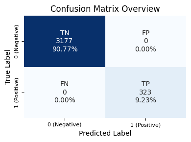

```python
# Generating a confusion matrix overview for the Decision Tree model trained with 'Experience' dropped
# This evaluates the model's predictions on the training dataset (X_train_with_dropped_experience, y_train)
# Displays a heatmap with the confusion matrix values and percentages
confusion_matrix_overview(decision_tree_with_dropped_experience, X_train_with_dropped_experience, y_train)
```

```python
# Evaluating the performance of the Decision Tree model trained with 'Experience' dropped on the training dataset
decision_tree_train_metrics_with_dropped_experience = model_metrics_overview(
    decision_tree_with_dropped_experience, X_train_with_dropped_experience, y_train
)

# Displaying the calculated metrics for the Decision Tree model with 'Experience' dropped
print("Displaying the calculated metrics for the Decision Tree model with 'Experience' dropped")
decision_tree_train_metrics_with_dropped_experience
```

```
Displaying the calculated metrics for the Decision Tree model with 'Experience' dropped
```

|  | Accuracy | Recall | Precision | F1 |
| --- | --- | --- | --- | --- |
| 0 | 1.0 | 1.0 | 1.0 | 1.0 |

```python
# Evaluating the performance of the Decision Tree model trained with 'Experience' dropped on the test dataset
decision_tree_test_metrics_with_dropped_experience = model_metrics_overview(
    decision_tree_with_dropped_experience, X_test_with_dropped_experience, y_test
)

# Displaying the calculated metrics for the Decision Tree model with 'Experience' dropped
print("Displaying the calculated metrics for the Decision Tree model with 'Experience' dropped")
decision_tree_test_metrics_with_dropped_experience
```

```
Displaying the calculated metrics for the Decision Tree model with 'Experience' dropped
```

|  | Accuracy | Recall | Precision | F1 |
| --- | --- | --- | --- | --- |
| 0 | 0.978667 | 0.872611 | 0.919463 | 0.895425 |

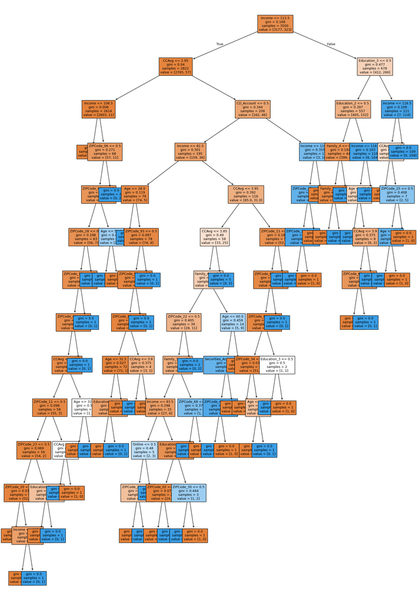

```python
# Setting the figure size for the Decision Tree visualization
plt.figure(figsize=(20, 30))

# Visualizing the trained Decision Tree model
# 'plot_tree' generates a graphical representation of the decision tree
# - feature_names: Names of the features used in the splits
# - filled=True: Adds color to the nodes for easier interpretation
# - fontsize=9: Adjusts font size for readability
decision_tree_visual = tree.plot_tree(
    decision_tree_with_dropped_experience,
    feature_names=feature_names_with_dropped_experience,
    filled=True,
    fontsize=9,
    node_ids=False,
    class_names=None,  # You can add target class names if available
)

# Ensuring arrows between nodes are properly formatted
# Some arrows may lack properties, so we explicitly set edge color and line width
for node in decision_tree_visual:
    arrow = node.arrow_patch
    if arrow is not None:
        arrow.set_edgecolor("black")  # Set arrow edge color to black
        arrow.set_linewidth(1)       # Set arrow line width for better visibility

# Displaying the Decision Tree visualization
plt.show()
```

```python
# Printing a text-based representation of the trained Decision Tree model
# 'export_text' generates a text summary of the tree structure:
# - feature_names: Names of the features used in the splits
# - show_weights=True: Displays the number of samples and class distribution at each node
tree_structure = tree.export_text(decision_tree_with_dropped_experience, feature_names=feature_names_with_dropped_experience, show_weights=True)

# Printing the tree structure for review
print(tree_structure)
```

```
|--- Income <= 113.50
|   |--- CCAvg <= 2.95
|   |   |--- Income <= 106.50
|   |   |   |--- weights: [2546.00, 0.00] class: 0
|   |   |--- Income >  106.50
|   |   |   |--- ZIPCode_06 <= 0.50
|   |   |   |   |--- ZIPCode_96 <= 0.50
|   |   |   |   |   |--- ZIPCode_28 <= 0.50
|   |   |   |   |   |   |--- ZIPCode_10 <= 0.50
|   |   |   |   |   |   |   |--- ZIPCode_49 <= 0.50
|   |   |   |   |   |   |   |   |--- CCAvg <= 2.73
|   |   |   |   |   |   |   |   |   |--- ZIPCode_11 <= 0.50
|   |   |   |   |   |   |   |   |   |   |--- ZIPCode_23 <= 0.50
|   |   |   |   |   |   |   |   |   |   |   |--- truncated branch of depth 3
|   |   |   |   |   |   |   |   |   |   |--- ZIPCode_23 >  0.50
|   |   |   |   |   |   |   |   |   |   |   |--- truncated branch of depth 2
|   |   |   |   |   |   |   |   |   |--- ZIPCode_11 >  0.50
|   |   |   |   |   |   |   |   |   |   |--- CCAvg <= 1.30
|   |   |   |   |   |   |   |   |   |   |   |--- weights: [0.00, 1.00] class: 1
|   |   |   |   |   |   |   |   |   |   |--- CCAvg >  1.30
|   |   |   |   |   |   |   |   |   |   |   |--- weights: [1.00, 0.00] class: 0
|   |   |   |   |   |   |   |   |--- CCAvg >  2.73
|   |   |   |   |   |   |   |   |   |--- Age <= 32.50
|   |   |   |   |   |   |   |   |   |   |--- weights: [1.00, 0.00] class: 0
|   |   |   |   |   |   |   |   |   |--- Age >  32.50
|   |   |   |   |   |   |   |   |   |   |--- weights: [0.00, 1.00] class: 1
|   |   |   |   |   |   |   |--- ZIPCode_49 >  0.50
|   |   |   |   |   |   |   |   |--- weights: [0.00, 1.00] class: 1
|   |   |   |   |   |   |--- ZIPCode_10 >  0.50
|   |   |   |   |   |   |   |--- weights: [0.00, 1.00] class: 1
|   |   |   |   |   |--- ZIPCode_28 >  0.50
|   |   |   |   |   |   |--- weights: [0.00, 1.00] class: 1
|   |   |   |   |--- ZIPCode_96 >  0.50
|   |   |   |   |   |--- Age <= 50.00
|   |   |   |   |   |   |--- weights: [0.00, 2.00] class: 1
|   |   |   |   |   |--- Age >  50.00
|   |   |   |   |   |   |--- weights: [1.00, 0.00] class: 0
|   |   |   |--- ZIPCode_06 >  0.50
|   |   |   |   |--- weights: [0.00, 2.00] class: 1
|   |--- CCAvg >  2.95
```

[output cut: 114 more lines]

```
|   |   |   |   |--- weights: [0.00, 100.00] class: 1
|   |--- Education_3 >  0.50
|   |   |--- Income <= 116.50
|   |   |   |--- CCAvg <= 1.10
|   |   |   |   |--- weights: [5.00, 0.00] class: 0
|   |   |   |--- CCAvg >  1.10
|   |   |   |   |--- ZIPCode_25 <= 0.50
|   |   |   |   |   |--- Age <= 58.50
|   |   |   |   |   |   |--- weights: [0.00, 5.00] class: 1
|   |   |   |   |   |--- Age >  58.50
|   |   |   |   |   |   |--- weights: [1.00, 0.00] class: 0
|   |   |   |   |--- ZIPCode_25 >  0.50
|   |   |   |   |   |--- weights: [1.00, 0.00] class: 0
|   |   |--- Income >  116.50
|   |   |   |--- weights: [0.00, 109.00] class: 1
```

```python
filter_important_features(decision_tree_with_dropped_experience, X_train_with_dropped_experience.columns)
```

|  | Feature | Importance |
| --- | --- | --- |
| 0 | Income | 0.302919 |
| 1 | Education_2 | 0.220064 |
| 2 | Education_3 | 0.153567 |
| 3 | Family_3 | 0.078100 |
| 4 | Family_4 | 0.076538 |
| 5 | CCAvg | 0.060441 |
| 6 | Age | 0.021213 |
| 7 | CD_Account | 0.014207 |
| 8 | ZIPCode_11 | 0.010093 |
| 9 | ZIPCode_10 | 0.005929 |
| 10 | ZIPCode_06 | 0.004938 |
| 11 | ZIPCode_22 | 0.003706 |
| 12 | ZIPCode_02 | 0.003274 |
| 13 | ZIPCode_53 | 0.003192 |
| 14 | ZIPCode_93 | 0.003110 |
| 15 | ZIPCode_85 | 0.003105 |
| 16 | ZIPCode_42 | 0.003070 |
| 17 | ZIPCode_96 | 0.003015 |
| 18 | ZIPCode_65 | 0.002923 |
| 19 | ZIPCode_49 | 0.002922 |
| 20 | ZIPCode_20 | 0.002892 |
| 21 | ZIPCode_28 | 0.002738 |
| 22 | ZIPCode_35 | 0.002584 |
| 23 | ZIPCode_68 | 0.002558 |
| 24 | Securities_Account | 0.002512 |
| 25 | ZIPCode_30 | 0.002274 |
| 26 | ZIPCode_25 | 0.002030 |
| 27 | Online | 0.001819 |
| 28 | ZIPCode_09 | 0.001518 |
| 29 | ZIPCode_34 | 0.001071 |
| 30 | ZIPCode_23 | 0.000958 |
| 31 | ZIPCode_03 | 0.000721 |

#### **Model Performance**

- Both the model with **‘Experience’ retained** and the model with **‘Experience’ dropped** achieve perfect performance (Accuracy, Recall, Precision, and F1 all equal 1.0) on the training dataset.
- This suggests that both models are **overfitting** to the training data, memorizing the patterns rather than generalizing. Decision Trees are prone to overfitting, especially with complex datasets and no constraints like pruning or parameter tuning.

## Model Performance Improvement

### Pre-Pruning

#### Finding best hyperparameters

```python
# For the Decision Tree trained with 'Experience' retained
# Print the depth of the decision tree
# 'get_depth()' returns the maximum depth of the tree, which indicates its complexity
print("Tree depth (with Experience):", decision_tree_with_experience.get_depth())

# Print the number of leaf nodes in the decision tree
# 'get_n_leaves()' returns the total number of leaf nodes, representing the endpoints of the tree
print("Number of leaf nodes (with Experience):", decision_tree_with_experience.get_n_leaves())

# Print the minimum number of samples required to split an internal node
# 'min_samples_split' is a hyperparameter of the decision tree that controls overfitting
print(
    "Minimum samples required to split (with Experience):",
    decision_tree_with_experience.min_samples_split,
)

# For the Decision Tree trained with 'Experience' dropped
# Print the depth of the decision tree
print("\nTree depth (without Experience):", decision_tree_with_dropped_experience.get_depth())

# Print the number of leaf nodes in the decision tree
print("Number of leaf nodes (without Experience):", decision_tree_with_dropped_experience.get_n_leaves())

# Print the minimum number of samples required to split an internal node
print(
    "Minimum samples required to split (without Experience):",
    decision_tree_with_dropped_experience.min_samples_split,
)
```

```
Tree depth (with Experience): 13
Number of leaf nodes (with Experience): 63
Minimum samples required to split (with Experience): 2

Tree depth (without Experience): 13
Number of leaf nodes (without Experience): 63
Minimum samples required to split (without Experience): 2
```

```python
# Define the parameter grid for the Decision Tree
# 'max_depth_values' specifies the range of tree depths to explore
# 'max_leaf_nodes_values' specifies the number of leaf nodes to test for limiting the tree size
# 'min_samples_split_values' specifies the minimum number of samples required to split an internal node
max_depth_values = np.arange(3, 10)
max_leaf_nodes_values = [20, 30, 40, 50]
min_samples_split_values = [5, 10, 30, 50]

# Initialize variables to track the best model and performance for each feature set
best_estimator_with_experience = None          # To store the best decision tree model with 'Experience'
best_estimator_with_dropped_experience = None  # To store the best decision tree model with 'Experience' dropped
best_score_diff_with_experience = float('inf')  # Track smallest recall score difference with 'Experience'
best_score_diff_with_dropped_experience = float('inf')  # Track smallest recall score difference with 'Experience' dropped
best_test_score_with_experience = 0.0          # Track the best test recall score with 'Experience'
best_test_score_with_dropped_experience = 0.0  # Track the best test recall score with 'Experience' dropped

# Perform grid search by iterating over all combinations of the parameters for both feature sets
for max_depth in max_depth_values:
    for max_leaf_nodes in max_leaf_nodes_values:
        for min_samples_split in min_samples_split_values:

            # Initialize a Decision Tree for the feature set with 'Experience' retained
            estimator_with_experience = DecisionTreeClassifier(
                max_depth=max_depth,
                max_leaf_nodes=max_leaf_nodes,
                min_samples_split=min_samples_split,
                random_state=42  # Set a fixed seed for reproducibility
            )

            # Initialize a Decision Tree for the feature set with 'Experience' dropped
            estimator_with_dropped_experience = DecisionTreeClassifier(
                max_depth=max_depth,
                max_leaf_nodes=max_leaf_nodes,
                min_samples_split=min_samples_split,
                random_state=42  # Set a fixed seed for reproducibility
            )

            # Fit both models to the training data
            estimator_with_experience.fit(X_train_with_experience, y_train)
            estimator_with_dropped_experience.fit(X_train_with_dropped_experience, y_train)

            # Make predictions on the training and test datasets for both models
            y_train_pred_with_experience = estimator_with_experience.predict(X_train_with_experience)
            y_test_pred_with_experience = estimator_with_experience.predict(X_test_with_experience)

            y_train_pred_with_dropped_experience = estimator_with_dropped_experience.predict(X_train_with_dropped_experience)
            y_test_pred_with_dropped_experience = estimator_with_dropped_experience.predict(X_test_with_dropped_experience)

            # Calculate recall scores for training and test datasets for both models
            train_recall_score_with_experience = recall_score(y_train, y_train_pred_with_experience)
            test_recall_score_with_experience = recall_score(y_test, y_test_pred_with_experience)

            train_recall_score_with_dropped_experience = recall_score(y_train, y_train_pred_with_dropped_experience)
            test_recall_score_with_dropped_experience = recall_score(y_test, y_test_pred_with_dropped_experience)

            # Calculate the absolute difference between training and test recall scores for both models
            score_diff_with_experience = abs(train_recall_score_with_experience - test_recall_score_with_experience)
            score_diff_with_dropped_experience = abs(train_recall_score_with_dropped_experience - test_recall_score_with_dropped_experience)

            # Update the best models if the recall score difference is smaller and the test recall is better
            if (score_diff_with_experience < best_score_diff_with_experience) & (test_recall_score_with_experience > best_test_score_with_experience):
                best_score_diff_with_experience = score_diff_with_experience
                best_test_score_with_experience = test_recall_score_with_experience
                best_estimator_with_experience = estimator_with_experience

            if (score_diff_with_dropped_experience < best_score_diff_with_dropped_experience) & (test_recall_score_with_dropped_experience > best_test_score_with_dropped_experience):
                best_score_diff_with_dropped_experience = score_diff_with_dropped_experience
                best_test_score_with_dropped_experience = test_recall_score_with_dropped_experience
                best_estimator_with_dropped_experience = estimator_with_dropped_experience

# Print the best parameters and corresponding test recall score for both feature sets
print("Best parameters for the model with 'Experience' retained:")
print(f"Max depth: {best_estimator_with_experience.max_depth}")
print(f"Max leaf nodes: {best_estimator_with_experience.max_leaf_nodes}")
print(f"Min samples split: {best_estimator_with_experience.min_samples_split}")
print(f"Best test recall score with 'Experience': {best_test_score_with_experience}")

print("\nBest parameters for the model with 'Experience' dropped:")
print(f"Max depth: {best_estimator_with_dropped_experience.max_depth}")
print(f"Max leaf nodes: {best_estimator_with_dropped_experience.max_leaf_nodes}")
print(f"Min samples split: {best_estimator_with_dropped_experience.min_samples_split}")
print(f"Best test recall score with 'Experience' dropped: {best_test_score_with_dropped_experience}")
```

```
Best parameters for the model with 'Experience' retained:
Max depth: 4
Max leaf nodes: 20
Min samples split: 5
Best test recall score with 'Experience': 0.7834394904458599

Best parameters for the model with 'Experience' dropped:
Max depth: 5
Max leaf nodes: 20
Min samples split: 5
Best test recall score with 'Experience' dropped: 0.8662420382165605
```

#### Train model with **Experience**

```python
# Pre-pruned Decision Tree Model for the feature set with 'Experience' retained
# Using the best estimator found during the grid search as the pre-pruned model for 'Experience' retained
pre_pruned_decision_tree_with_experience = best_estimator_with_experience

# Train the pre-pruned Decision Tree on the training data with 'Experience' retained
# The model is limited by the pre-pruning parameters (e.g., max depth, max leaf nodes, min samples split)
pre_pruned_decision_tree_with_experience.fit(X_train_with_experience, y_train)
```

```
DecisionTreeClassifier(max_depth=4, max_leaf_nodes=20, min_samples_split=5,
                       random_state=42)
```

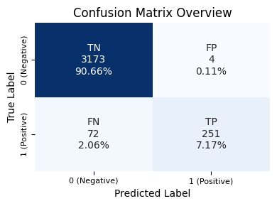

```python
# Generate a confusion matrix overview for the pre-pruned Decision Tree with 'Experience' retained on the training data
# This function displays a heatmap of the confusion matrix with counts and percentages
# It evaluates how well the pre-pruned model (pre_pruned_decision_tree_with_experience) performs on the training dataset
confusion_matrix_overview(pre_pruned_decision_tree_with_experience, X_train_with_experience, y_train)
```

```python
# Evaluate performance metrics for the pre-pruned Decision Tree with 'Experience' retained on the training dataset
# The function calculates key classification metrics: Accuracy, Recall, Precision, and F1 score
pre_pruned_train_metrics_with_experience = model_metrics_overview(pre_pruned_decision_tree_with_experience, X_train_with_experience, y_train)

# Display the calculated training metrics for the pre-pruned model with 'Experience' retained
print("Display the calculated training metrics for the pre-pruned model with 'Experience' retained")
pre_pruned_train_metrics_with_experience
```

```
Display the calculated training metrics for the pre-pruned model with 'Experience' retained
```

|  | Accuracy | Recall | Precision | F1 |
| --- | --- | --- | --- | --- |
| 0 | 0.978286 | 0.77709 | 0.984314 | 0.868512 |

```python
# Evaluate performance metrics for the pre-pruned Decision Tree with 'Experience' retained on the test dataset
# The function calculates key classification metrics: Accuracy, Recall, Precision, and F1 score
pre_pruned_test_metrics_with_experience = model_metrics_overview(
    pre_pruned_decision_tree_with_experience, X_test_with_experience, y_test
)

# Display the calculated test metrics for the pre-pruned model with 'Experience' retained
print("Display the calculated test metrics for the pre-pruned model with 'Experience' retained")
pre_pruned_test_metrics_with_experience
```

```
Display the calculated test metrics for the pre-pruned model with 'Experience' retained
```

|  | Accuracy | Recall | Precision | F1 |
| --- | --- | --- | --- | --- |
| 0 | 0.973333 | 0.783439 | 0.953488 | 0.86014 |

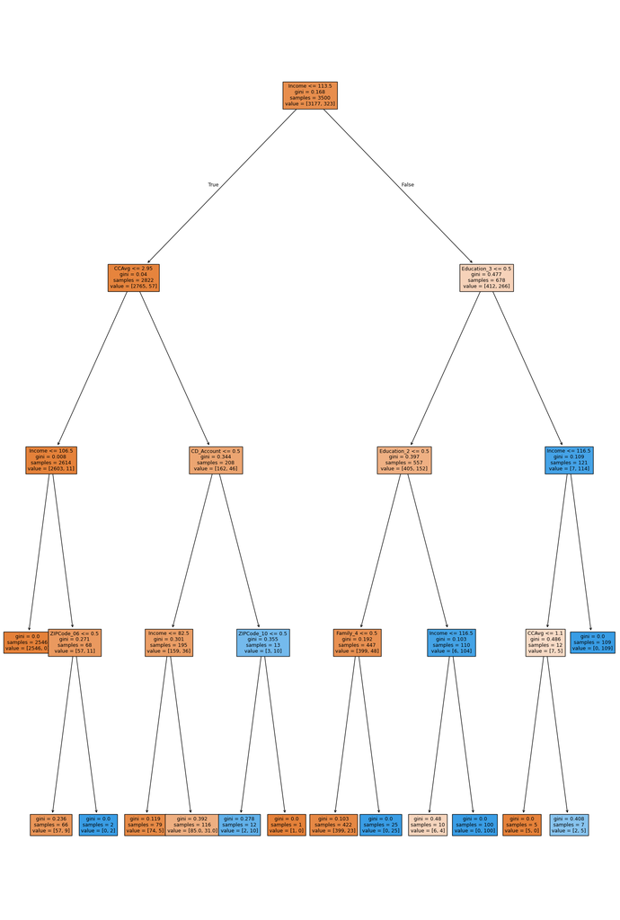

```python
# Visualize the pre-pruned Decision Tree structure
plt.figure(figsize=(20, 30))  # Set the figure size to ensure the tree is clearly visible

# Generate the decision tree visualization
# - 'pre_pruned_decision_tree': The trained Decision Tree model to visualize
# - 'feature_names': List of feature names used for training the model
# - 'filled=True': Colors the nodes based on their classification to enhance interpretability
# - 'fontsize=9': Adjusts font size for better readability
dt_tree_visualization = tree.plot_tree(
    pre_pruned_decision_tree_with_experience,
    feature_names=feature_names_with_experience,
    filled=True,
    fontsize=9,
    node_ids=False,  # Do not show node IDs
    class_names=None,  # Do not display class names explicitly
)

# Enhance visualization by ensuring all decision tree splits have arrows
# Some arrows may be missing by default; this ensures all are visible
for node in dt_tree_visualization:
    arrow = node.arrow_patch  # Get the arrow for the current node
    if arrow is not None:  # If an arrow exists, customize its appearance
        arrow.set_edgecolor("black")  # Set the arrow edge color to black
        arrow.set_linewidth(1)  # Set the arrow line width for better visibility

# Display the tree visualization
plt.show()
```

```python
# Print a textual representation of the pre-pruned Decision Tree
# - 'pre_pruned_decision_tree': The trained Decision Tree model to export
# - 'feature_names': List of feature names used in the model
# - 'show_weights=True': Includes the number of samples and class distributions at each node
# This textual representation provides an interpretable view of the tree structure
print(tree.export_text(pre_pruned_decision_tree_with_experience, feature_names=feature_names_with_experience, show_weights=True))
```

```
|--- Income <= 113.50
|   |--- CCAvg <= 2.95
|   |   |--- Income <= 106.50
|   |   |   |--- weights: [2546.00, 0.00] class: 0
|   |   |--- Income >  106.50
|   |   |   |--- ZIPCode_06 <= 0.50
|   |   |   |   |--- weights: [57.00, 9.00] class: 0
|   |   |   |--- ZIPCode_06 >  0.50
|   |   |   |   |--- weights: [0.00, 2.00] class: 1
|   |--- CCAvg >  2.95
|   |   |--- CD_Account <= 0.50
|   |   |   |--- Income <= 82.50
|   |   |   |   |--- weights: [74.00, 5.00] class: 0
|   |   |   |--- Income >  82.50
|   |   |   |   |--- weights: [85.00, 31.00] class: 0
|   |   |--- CD_Account >  0.50
|   |   |   |--- ZIPCode_10 <= 0.50
|   |   |   |   |--- weights: [2.00, 10.00] class: 1
|   |   |   |--- ZIPCode_10 >  0.50
|   |   |   |   |--- weights: [1.00, 0.00] class: 0
|--- Income >  113.50
|   |--- Education_3 <= 0.50
|   |   |--- Education_2 <= 0.50
|   |   |   |--- Family_4 <= 0.50
|   |   |   |   |--- weights: [399.00, 23.00] class: 0
|   |   |   |--- Family_4 >  0.50
|   |   |   |   |--- weights: [0.00, 25.00] class: 1
|   |   |--- Education_2 >  0.50
|   |   |   |--- Income <= 116.50
|   |   |   |   |--- weights: [6.00, 4.00] class: 0
|   |   |   |--- Income >  116.50
|   |   |   |   |--- weights: [0.00, 100.00] class: 1
|   |--- Education_3 >  0.50
|   |   |--- Income <= 116.50
|   |   |   |--- CCAvg <= 1.10
|   |   |   |   |--- weights: [5.00, 0.00] class: 0
|   |   |   |--- CCAvg >  1.10
|   |   |   |   |--- weights: [2.00, 5.00] class: 1
|   |   |--- Income >  116.50
|   |   |   |--- weights: [0.00, 109.00] class: 1
```

```python
filter_important_features(pre_pruned_decision_tree_with_experience, X_train_with_experience.columns)
```

|  | Feature | Importance |
| --- | --- | --- |
| 0 | Income | 0.374134 |
| 1 | Education_2 | 0.268666 |
| 2 | Education_3 | 0.192932 |
| 3 | Family_4 | 0.091426 |
| 4 | CCAvg | 0.045742 |
| 5 | CD_Account | 0.018049 |
| 6 | ZIPCode_06 | 0.006274 |
| 7 | ZIPCode_10 | 0.002778 |